# 성별에 따른 국내여행 참여 비교

# 성별에 따른 국내여행 참여자 차이 : 데이터 주제 : <여행지별 국내여행 참가자수(2014~2016)>

데이터 선정 이유 : 근래의 국내 여행 시장 약화 추세로 인해 국내 여행 진흥을 위한 다양한 시도가 이루어지고 있다. 그만큼 실질적인 국내 여행 참가자들의 데이터의 중요성도 높아졌기에 이를 알아 봄으로써 국내 여행자들의 특성에 대한 파악을 할 수 있다. 우리 조는 국내 여행이 얼마나 활성화 되어있는지 또 국내 여행자의 다양한 특성들에 대해 궁금증을 가져 이 데이터를 사용하게 되었다.

국가통계포털(KOSIS)제공

데이터 위치 : 국내통계-기관별통계-중앙행정기관-문화체육관광부-국민여행 실태조사-여행 경험률 및 여행참가 횟수-여행지별 국내여행 참가자수(2014~2016)

2014년부터 2016년까지의 국내여행 참가자들을 대상으로 한 데이터

대한민국 전국 시도별 국내 여행 참가자수를 통계분류(1)과 그 하위항목 분류인 통계분류(2)로 자세히 나눔

국내 여행지(17곳) : 서울, 부산, 대구, 인천, 광주, 대전, 울산, 세종, 경기, 강원, 충북, 충남, 전북, 전남, 경북, 경남, 제주

통계분류

1. 성별 (남자, 여자)
2. 연령(15세~19세, 20대, 30대, 40대, 50대, 60대이상)
3. 직업(전문관리, 사무, 서비스판매, 농어업, 기능노무)
4. 가구소득(50만원미만, 50만~100만원미만, 100만~200만원미만, 200만~300만원미만, 300만~400만원미만, 400만~500만원미만, 500만~600만원미만, 600만원 이상)
5. 학력(초졸이하, 중학교(재/졸), 고등학교(재/졸), 전문대(재/졸), 대학교(재/졸), 대학원(재/졸)

조사목적 : 우리나라 국민의 여행실태를 종합적으로 파악, 국가 관광에 관한 정책수립과 연구·분석 등을 위한 기초 자료를 제공

조사주기 : 1년

조사체계 : 통계조사용역기관→문화체육관광부

통계종류 : 일반통계

조사대상 범위 : 가구 내 만 15세 이상 모든 가구원 조사

조사대장 지역 : 전국

### 패키지 불러오기

```r
library(ggplot2)
library(readxl)
library(dplyr)
```

### 엑셀 파일 불러오기

```r
local <- read_excel("local trip_2014~2016.xlsx", sheet = 1, col_names = T)
str(local)
```

```
## Classes 'tbl_df', 'tbl' and 'data.frame':    29 obs. of  53 variables:
##  $ 통계분류(1): chr  "통계분류(1)" "전체" "성별" NA ...
##  $ 통계분류(2): chr  "통계분류(2)" "소계" "남자" "여자" ...
##  $ 2014       : chr  "서울" "12580581" "5679692" "6900889" ...
##  $ 2014__1    : chr  "부산" "6665173" "3186234" "3478939" ...
##  $ 2014__2    : chr  "대구" "3554687" "1704851" "1849836" ...
##  $ 2014__3    : chr  "인천" "4464192" "2085968" "2378224" ...
##  $ 2014__4    : chr  "광주" "2263117" "1158819" "1104298" ...
##  $ 2014__5    : chr  "대전" "3123627" "1508478" "1615149" ...
##  $ 2014__6    : chr  "울산" "1787673" "830784" "956889" ...
##  $ 2014__7    : chr  "세종" "366885" "209194" "157691" ...
##  $ 2014__8    : chr  "경기" "15283727" "7186353" "8097374" ...
##  $ 2014__9    : chr  "강원" "12282959" "5990236" "6292723" ...
##  $ 2014__10   : chr  "충북" "5212064" "2368343" "2843721" ...
##  $ 2014__11   : chr  "충남" "9758248" "4799826" "4958422" ...
```

[output cut: 39 more lines]

### 필요없는 행과 열 정리

```r
local <- local[c(1:4),]
local <- local[,-c(1)]
```

## 데이터 확인

```r
View(local)
```

### local에서 man 데이터 추출

```r
man <- c(5679692,
         3186234,
         1704851,
         2085968,
         1158819,
         1508478,
         830784,
         209194,
         7186353,
         5990236,
         2368343,
         4799826,
         3622001,
         3445811,
         4684999,
         4670726,
         1651470,
         5936500,
         3480070,
         1507886,
         1990424,
         985757,
         1433309,
         781214,
         94068,
         7334898,
         5663455,
         2322692,
         4783462,
         3230798,
         3834223,
         4191480,
         4148802,
         2074122,
         6153648,
         3481215,
         1600432,
         2566923,
         1163528,
         1682066,
         995151,
         362288,
         7985308,
         5747317,
         2583590,
         4865165,
         3501966,
         4232213,
         3961299,
         4538624,
         2208882)
```

### local에서 woman 데이터 추출

```r
woman <- c(6900889,
           3478939,
           1849836,
           2378224,
           1104298,
           1615149,
           956889,
           157691,
           8097374,
           6292723,
           2843721,
           4958422,
           4209072,
           3884633,
           4943875,
           5018457,
           2026254,
           6515391,
           3678483,
           1655275,
           2416639,
           1149575,
           1551620,
           851196,
           239261,
           8116857,
           5895550,
           2818418,
           5161154,
           3530032,
           4229315,
           4630721,
           4330765,
           2658372,
           7084206,
           3932941,
           1537255,
           2853783,
           1237716,
           1815821,
           1048806,
           378422,
           8841398,
           5935906,
           2995599,
           5327268,
           4209060,
           4847903,
           4698537,
           4943734,
           2621070)
```

### local에서 지역 데이터 추출

```r
local_region <- c("서울",
                  "부산",
                  "대구",
                  "인천",
                  "광주",
                  "대전",
                  "울산",
                  "세종",
                  "경기",
                  "강원",
                  "충북",
                  "충남",
                  "전북",
                  "전남",
                  "경북",
                  "경남",
                  "제주",
                  "서울",
                  "부산",
                  "대구",
                  "인천",
                  "광주",
                  "대전",
                  "울산",
                  "세종",
                  "경기",
                  "강원",
                  "충북",
                  "충남",
                  "전북",
                  "전남",
                  "경북",
                  "경남",
                  "제주",
                  "서울",
                  "부산",
                  "대구",
                  "인천",
                  "광주",
                  "대전",
                  "울산",
                  "세종",
                  "경기",
                  "강원",
                  "충북",
                  "충남",
                  "전북",
                  "전남",
                  "경북",
                  "경남",
                  "제주")
```

### 년도 데이터

```r
year <- c("2014","2014","2014","2014","2014","2014","2014","2014","2014","2014","2014","2014","2014","2014","2014","2014","2014",
          "2015","2015","2015","2015","2015","2015","2015","2015","2015","2015","2015","2015","2015","2015","2015","2015","2015",
          "2016","2016","2016","2016","2016","2016","2016","2016","2016","2016","2016","2016","2016","2016","2016","2016","2016")
```

## 변수들을 합쳐 데이터프레임 생성

```r
df_local_trip <- data.frame(man,woman,local_region,year)
df_local_trip
```

```
##        man   woman local_region year
## 1  5679692 6900889         서울 2014
## 2  3186234 3478939         부산 2014
## 3  1704851 1849836         대구 2014
## 4  2085968 2378224         인천 2014
## 5  1158819 1104298         광주 2014
## 6  1508478 1615149         대전 2014
## 7   830784  956889         울산 2014
## 8   209194  157691         세종 2014
## 9  7186353 8097374         경기 2014
## 10 5990236 6292723         강원 2014
## 11 2368343 2843721         충북 2014
## 12 4799826 4958422         충남 2014
## 13 3622001 4209072         전북 2014
## 14 3445811 3884633         전남 2014
```

[output cut: 37 more lines]

```r
head(df_local_trip)
```

```
##       man   woman local_region year
## 1 5679692 6900889         서울 2014
## 2 3186234 3478939         부산 2014
## 3 1704851 1849836         대구 2014
## 4 2085968 2378224         인천 2014
## 5 1158819 1104298         광주 2014
## 6 1508478 1615149         대전 2014
```

### 지역과 년도를 중심으로 차례대로 데이터 정리, 성별에 따른 각 지역 여행자수 평균 구함

```r
a <- df_local_trip %>% group_by(local_region, year) %>%  summarise(mean_man = mean(man), mean_woman = mean(woman))
a
```

```
## # A tibble: 51 x 4
## # Groups:   local_region [?]
##    local_region   year mean_man mean_woman
##          <fctr> <fctr>    <dbl>      <dbl>
##  1         강원   2014  5990236    6292723
##  2         강원   2015  5663455    5895550
##  3         강원   2016  5747317    5935906
##  4         경기   2014  7186353    8097374
##  5         경기   2015  7334898    8116857
##  6         경기   2016  7985308    8841398
##  7         경남   2014  4670726    5018457
##  8         경남   2015  4148802    4330765
##  9         경남   2016  4538624    4943734
## 10         경북   2014  4684999    4943875
## # ... with 41 more rows
```

### 위 데이터에서 파생변수 추가(지역별 평균값이 큰 성별, 지역별 성별 평균값 합)

```r
b <- a %>% mutate(compare = ifelse(mean_man>mean_woman, "man_larger", "woman_lager"), mean_all = (mean_man+mean_woman))
View(b)
```

## 연도별 변화를 알아보기 위해 연도별 분리

### 2014년

```r
year_compare2014 <- b %>% filter(year == "2014")
year_compare2014
```

```
## # A tibble: 17 x 6
## # Groups:   local_region [17]
##    local_region   year mean_man mean_woman     compare mean_all
##          <fctr> <fctr>    <dbl>      <dbl>       <chr>    <dbl>
##  1         강원   2014  5990236    6292723 woman_lager 12282959
##  2         경기   2014  7186353    8097374 woman_lager 15283727
##  3         경남   2014  4670726    5018457 woman_lager  9689183
##  4         경북   2014  4684999    4943875 woman_lager  9628874
##  5         광주   2014  1158819    1104298  man_larger  2263117
##  6         대구   2014  1704851    1849836 woman_lager  3554687
##  7         대전   2014  1508478    1615149 woman_lager  3123627
##  8         부산   2014  3186234    3478939 woman_lager  6665173
##  9         서울   2014  5679692    6900889 woman_lager 12580581
## 10         세종   2014   209194     157691  man_larger   366885
## 11         울산   2014   830784     956889 woman_lager  1787673
## 12         인천   2014  2085968    2378224 woman_lager  4464192
## 13         전남   2014  3445811    3884633 woman_lager  7330444
## 14         전북   2014  3622001    4209072 woman_lager  7831073
## 15         제주   2014  1651470    2026254 woman_lager  3677724
## 16         충남   2014  4799826    4958422 woman_lager  9758248
## 17         충북   2014  2368343    2843721 woman_lager  5212064
```

### 2015년

```r
year_compare2015 <- b %>% filter(year == "2015")
year_compare2015
```

```
## # A tibble: 17 x 6
## # Groups:   local_region [17]
##    local_region   year mean_man mean_woman     compare mean_all
##          <fctr> <fctr>    <dbl>      <dbl>       <chr>    <dbl>
##  1         강원   2015  5663455    5895550 woman_lager 11559005
##  2         경기   2015  7334898    8116857 woman_lager 15451755
##  3         경남   2015  4148802    4330765 woman_lager  8479567
##  4         경북   2015  4191480    4630721 woman_lager  8822201
##  5         광주   2015   985757    1149575 woman_lager  2135332
##  6         대구   2015  1507886    1655275 woman_lager  3163161
##  7         대전   2015  1433309    1551620 woman_lager  2984929
##  8         부산   2015  3480070    3678483 woman_lager  7158553
##  9         서울   2015  5936500    6515391 woman_lager 12451891
## 10         세종   2015    94068     239261 woman_lager   333329
## 11         울산   2015   781214     851196 woman_lager  1632410
## 12         인천   2015  1990424    2416639 woman_lager  4407063
## 13         전남   2015  3834223    4229315 woman_lager  8063538
## 14         전북   2015  3230798    3530032 woman_lager  6760830
## 15         제주   2015  2074122    2658372 woman_lager  4732494
## 16         충남   2015  4783462    5161154 woman_lager  9944616
## 17         충북   2015  2322692    2818418 woman_lager  5141110
```

### 2016년

```r
year_compare2016 <- b %>% filter(year == "2016")
year_compare2016
```

```
## # A tibble: 17 x 6
## # Groups:   local_region [17]
##    local_region   year mean_man mean_woman     compare mean_all
##          <fctr> <fctr>    <dbl>      <dbl>       <chr>    <dbl>
##  1         강원   2016  5747317    5935906 woman_lager 11683223
##  2         경기   2016  7985308    8841398 woman_lager 16826706
##  3         경남   2016  4538624    4943734 woman_lager  9482358
##  4         경북   2016  3961299    4698537 woman_lager  8659836
##  5         광주   2016  1163528    1237716 woman_lager  2401244
##  6         대구   2016  1600432    1537255  man_larger  3137687
##  7         대전   2016  1682066    1815821 woman_lager  3497887
##  8         부산   2016  3481215    3932941 woman_lager  7414156
##  9         서울   2016  6153648    7084206 woman_lager 13237854
## 10         세종   2016   362288     378422 woman_lager   740710
## 11         울산   2016   995151    1048806 woman_lager  2043957
## 12         인천   2016  2566923    2853783 woman_lager  5420706
## 13         전남   2016  4232213    4847903 woman_lager  9080116
## 14         전북   2016  3501966    4209060 woman_lager  7711026
## 15         제주   2016  2208882    2621070 woman_lager  4829952
## 16         충남   2016  4865165    5327268 woman_lager 10192433
## 17         충북   2016  2583590    2995599 woman_lager  5579189
```

## 연도별로 분리한 데이터를 시각화 위해 그래프로 생성 (x축은 지역, y축은 성별 평균합, 그래프의 색은 남/녀의 분리)

### 2014년 그래프

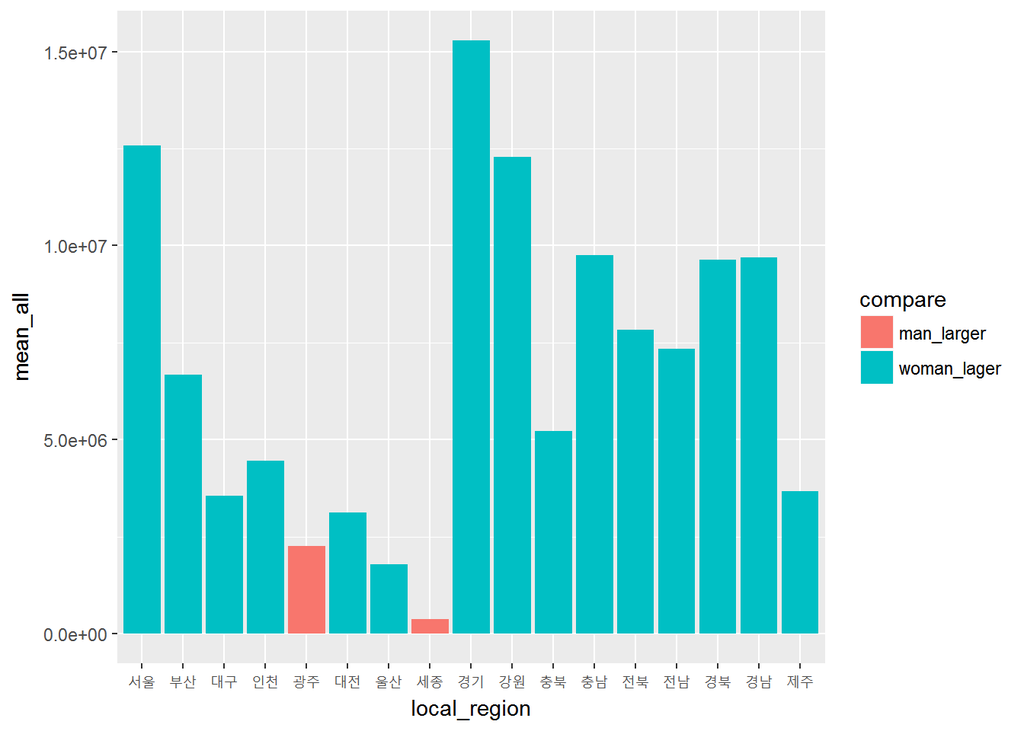

```r
ggplot(data=year_compare2014, aes(x=local_region, y=mean_all, fill=compare))+geom_col()+scale_x_discrete(limits=c("서울","부산","대구","인천","광주","대전","울산","세종","경기","강원","충북","충남","전북","전남","경북","경남","제주"))
```

### 2015년 그래프

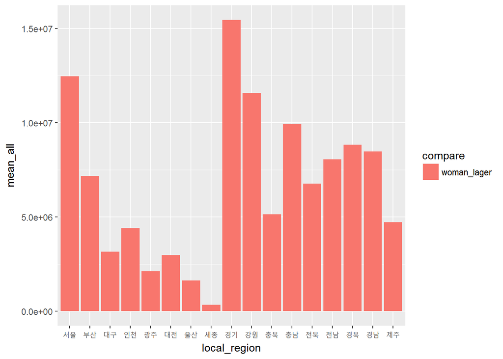

```r
ggplot(data=year_compare2015, aes(x=local_region, y=mean_all, fill=compare))+geom_col()+scale_x_discrete(limits=c("서울","부산","대구","인천","광주","대전","울산","세종","경기","강원","충북","충남","전북","전남","경북","경남","제주"))
```

### 2016년 그래프

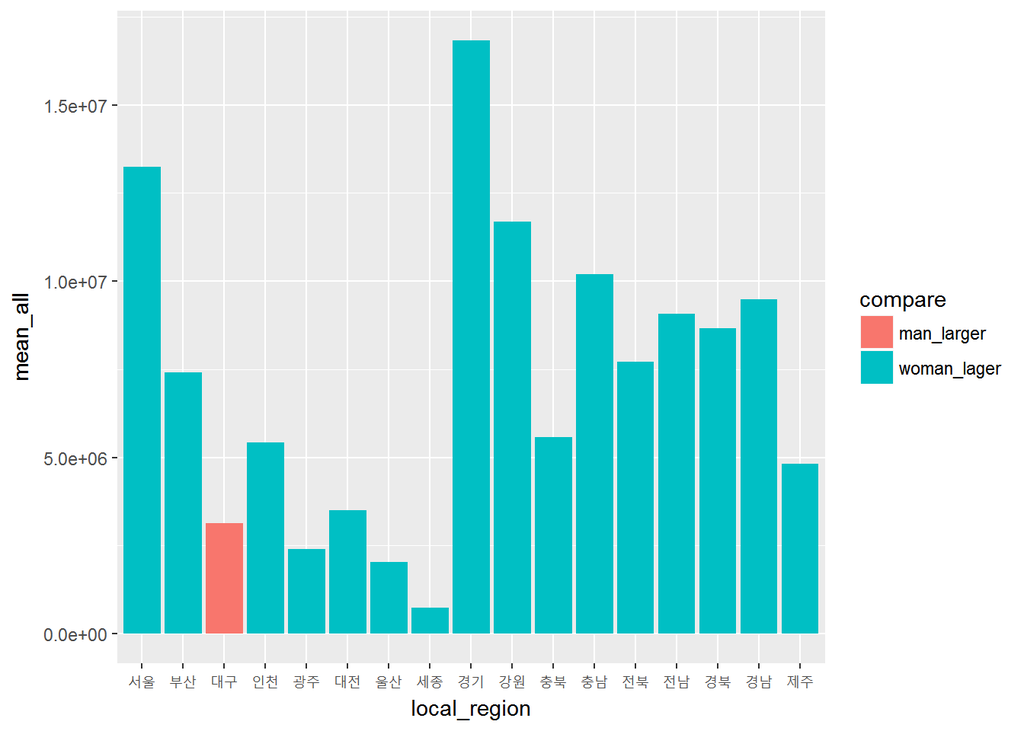

```r
ggplot(data=year_compare2016, aes(x=local_region, y=mean_all, fill=compare))+geom_col()+scale_x_discrete(limits=c("서울","부산","대구","인천","광주","대전","울산","세종","경기","강원","충북","충남","전북","전남","경북","경남","제주"))
```

### 2014년 지역별 성별에 따른 여행자 차이

남성 우위 지역 : 광주, 세종

여성 우위 지역 : 경기, 서울, 강원, 충남, 경북, 경남, 전북, 전남, 부산, 충북, 인천, 제주, 대구, 대전, 울산

### 2015년 지역별 성별에 따른 여행자 차이

남성 우위 지역 : 없음

여성 우위 지역 : 경기, 서울, 강원, 충남, 경북, 경남, 전남, 부산, 전북, 충북, 제주, 인천, 대구, 대전, 광주, 울산, 세종

### 2016년 지역별 성별에 따른 여행자 차이

남성 우위 지역 : 대구

여성 우위 지역 : 경기, 서울, 강원, 충남, 경남, 전남, 경북, 전북, 부산, 충북, 인천, 제주, 대전, 광주, 울산, 세종